# DA2: Assignment 1 by Abduvosid Malikov

## Introduction

This is the Assignment 1 for `Data Analysis 2` and `Coding` course. The aim of this project is to analyse the pattern of association between **registered COVID-19 cases** and **registered number of death** due to COVID-19 on 10-31-2020. As a source, [covid-19 data](https://github.com/CSSEGISandData/COVID-19/blob/master/csse_covid_19_data/csse_covid_19_daily_reports/10-31-2020.csv) from CSSE[^1] was used. The *population* is all cases reported in CSSE dataset starting from 01-22-2020 until now (the last added report date was 11-28-2020). The *sample* is the dataset that contains confirmed and death cases only from one date: 10-31-2020. The variables that are used are:

- country: string value showing the name of the country
- confirmed: numeric value showing the number of confirmed cases of COVID
- death: numeric value showing the number of death cases from COVID
- population: numeric value showing the population of the country
- ln_confirmed: log of number of confirmed cases
- ln_death: log of number of death cases

Invalid data (measuring flu cases instead of COVID), unreliable data (showing one value today and showing enormously different value tomorrow) and missing values are the potential data quality issues.

The dependent (y) variable is *Number of registered death* and explanatory (x) variable is *Number of confirmed case*. Figure 1 below shows the histogram for both variables

Both of the histograms have long right tail because majority of observations have almost same values and only few observations have extreme values. Most of the observations for confirmed cases are between 0 and 2 million, only 2 observations have a value more than 4 million. Most of the death cases are between 0 and 50000 and only 3 observations have a value more than 50000.

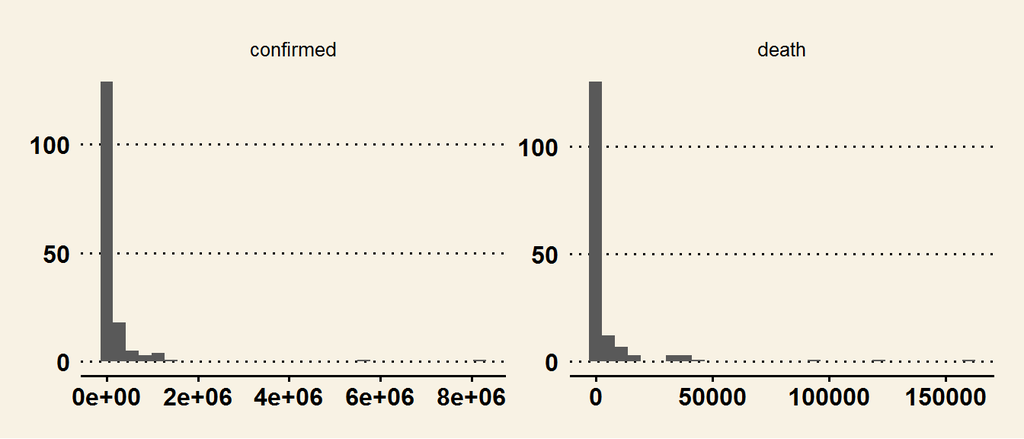

Histogram of confirmed and death cases

Tables below shows that on average there are 5472 death cases and 209452 registered cases. Mean is higher than median both for death numbers and registered cases indicating a skewed distribution with a long right tail.

Summary statistics on number of death

| mean | median | std | min | max |
| --- | --- | --- | --- | --- |
| 5472.488 | 320.5 | 18583.42 | 0 | 159884 |

Summary statistics on number of registered cases

| mean | median | std | min | max |
| --- | --- | --- | --- | --- |
| 209452 | 21334 | 799982.2 | 2 | 8184082 |

## Variable transformation

**level - level**

Substantive: distribution does not give meaningful interpretation

Statistical: there are some influential observations that governing the conditional mean. Graph is given in Appendix

**level y - log x:**

Substantive reasoning: level changes in death cases is harder to interpret

Statistical reasoning: log transformation shows the better approximation and capturing the non-linearity in data. Graph is given in Appendix

**log y - level x:**

Most of the observations are very close to each other at the bottom of the distribution of number of registered cases.

Substantive reasoning: level changes in registered cases is harder to interpret Statistical reasoning: log transformation of number of registered death and taking level of number of case does not give meaningful non-linear approximation. Graph is given in Appendix

**log y - log x**

Taking log of number of registered death and log of number of registered case is making the association close to linear

Substantive reasoning: it is easier to interpret the percentage change in number of death per percentage change in confirmed case

Statistical reasoning: it shows the better approximation: making the association close to linear

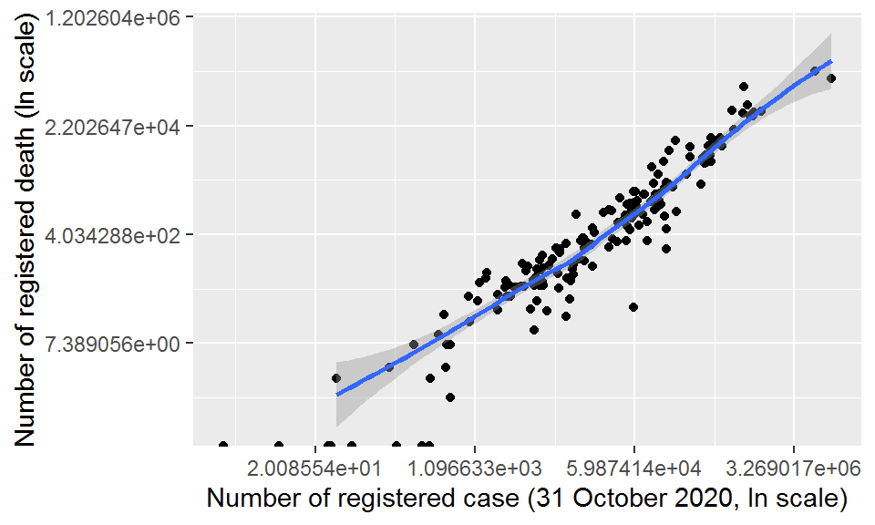

log y - log x transformation

## Estimating different models

Four different models were created.

First model illustrates Simple Linear Regression for log of number of death regressed on log of number of registered cases:

Regression model 1: ln_death = alpha + beta * ln_confirmed

R squared: 0.8944

Second model shows Quadratic (linear) regression for og of number of death regressed on log of number of registered cases:

Regression model 2: ln_death = alpha + beta_1 * ln_confirmed + beta_2 * ln_confirmed^2

R squared: 0.90

Third model is for Piecewise linear spline regression. 3 cutoff points (knots) were chosen: 8,12,14

R-squared: 0.9037

Fourth model demonstrates Weighted linear regression, using population as weights.

## Appendix

**level - level**

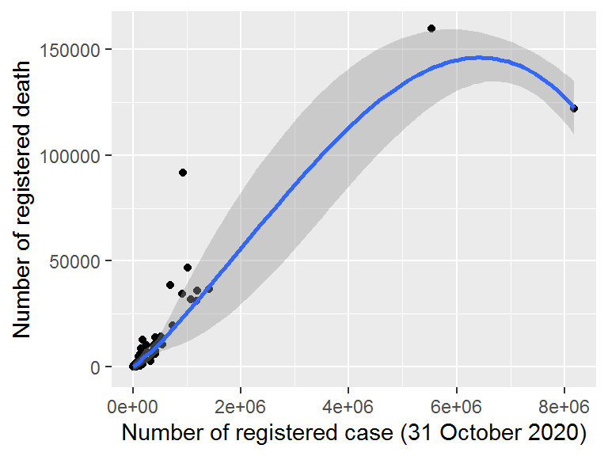

level - level distribution

**level - log transformation**

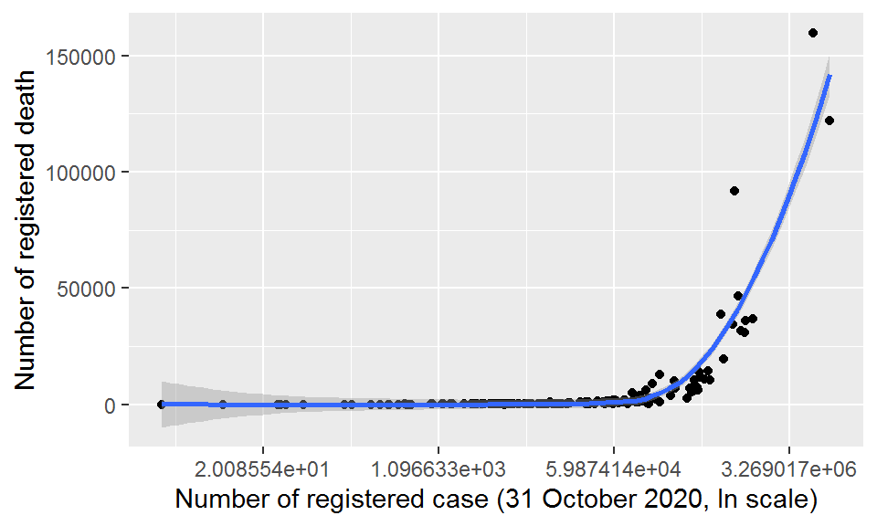

level -log transformation

**log y - level x transformation**

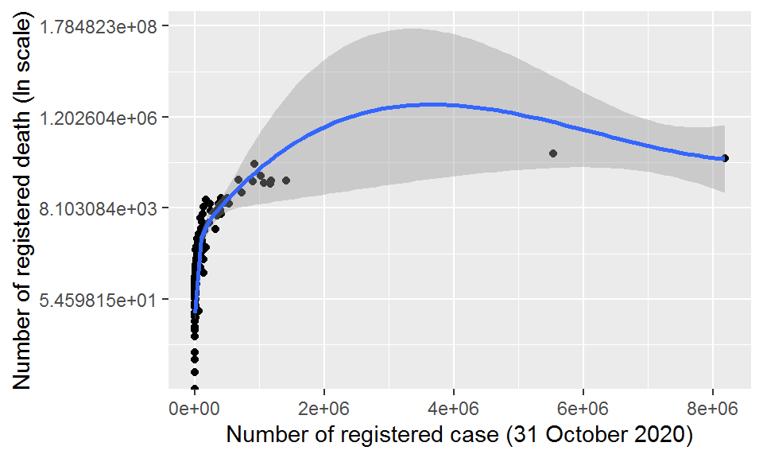

log y - level x transformation

```
##               Estimate Std. Error   t value     Pr(>|t|)   CI Lower  CI Upper
## (Intercept)  -4.406374 0.32435073 -13.58521 5.709025e-28 -5.0472256 -3.765522
## ln_confirmed  1.030951 0.03032022  34.00211 1.170499e-72  0.9710448  1.090858
##               DF
## (Intercept)  151
## ln_confirmed 151
```

```
##
## Call:
## lm_robust(formula = ln_death ~ ln_confirmed, data = df, se_type = "HC2")
##
## Standard error type:  HC2
##
## Coefficients:
##              Estimate Std. Error t value  Pr(>|t|) CI Lower CI Upper  DF
## (Intercept)    -4.406    0.32435  -13.59 5.709e-28   -5.047   -3.766 151
## ln_confirmed    1.031    0.03032   34.00 1.170e-72    0.971    1.091 151
##
## Multiple R-squared:  0.8944 ,    Adjusted R-squared:  0.8937
## F-statistic:  1156 on 1 and 151 DF,  p-value: < 2.2e-16
```

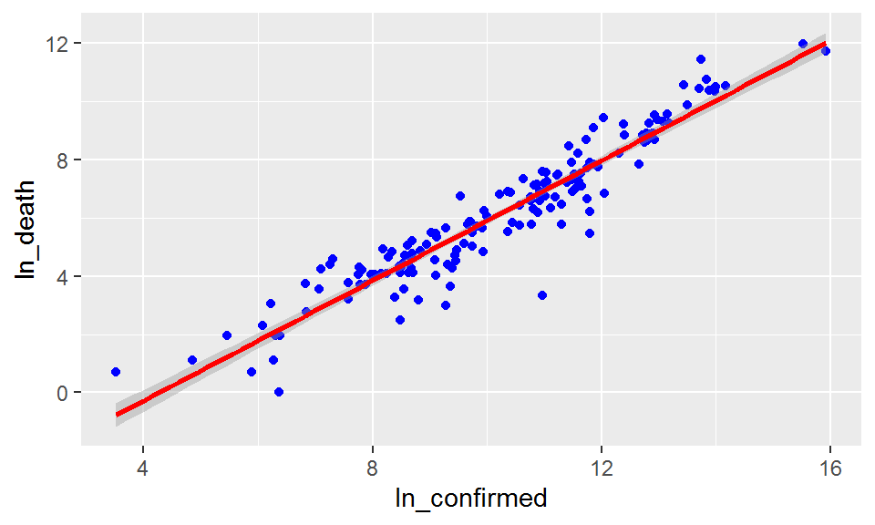

First model: Simple Linear Regression for ln_confirmed - ln_death

```
##
## Call:
## lm_robust(formula = ln_death ~ ln_confirmed + ln_confirmed_sq,
##     data = df)
##
## Standard error type:  HC2
##
## Coefficients:
##                 Estimate Std. Error t value Pr(>|t|) CI Lower CI Upper  DF
## (Intercept)     -1.59313    0.95714  -1.664 0.098107 -3.48435  0.29809 150
## ln_confirmed     0.44012    0.19101   2.304 0.022583  0.06271  0.81753 150
## ln_confirmed_sq  0.02949    0.00934   3.157 0.001928  0.01103  0.04794 150
##
## Multiple R-squared:  0.9009 ,    Adjusted R-squared:  0.8996
## F-statistic:   683 on 2 and 150 DF,  p-value: < 2.2e-16
```

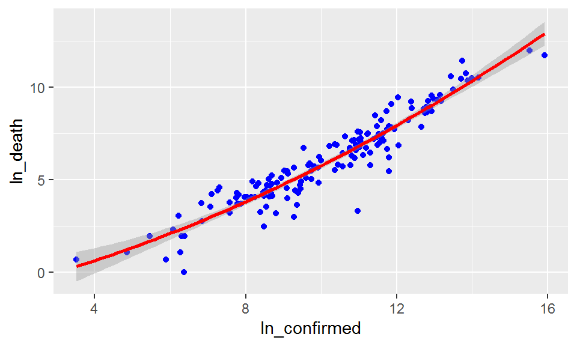

Second model: Quadratic (linear) regression for ln_confirmed - ln_death

```
##
## Call:
## lm_robust(formula = ln_death ~ lspline(ln_confirmed, cutoff),
##     data = df)
##
## Standard error type:  HC2
##
## Coefficients:
##                                Estimate Std. Error t value  Pr(>|t|) CI Lower
## (Intercept)                     -3.0891    0.93681  -3.297 1.222e-03  -4.9403
## lspline(ln_confirmed, cutoff)1   0.8650    0.12196   7.093 5.028e-11   0.6240
## lspline(ln_confirmed, cutoff)2   0.9744    0.05436  17.925 6.448e-39   0.8670
## lspline(ln_confirmed, cutoff)3   1.5269    0.12380  12.333 1.745e-24   1.2822
## lspline(ln_confirmed, cutoff)4   0.5918    0.16813   3.520 5.733e-04   0.2596
##                                CI Upper  DF
## (Intercept)                     -1.2378 148
## lspline(ln_confirmed, cutoff)1   1.1060 148
## lspline(ln_confirmed, cutoff)2   1.0819 148
## lspline(ln_confirmed, cutoff)3   1.7715 148
## lspline(ln_confirmed, cutoff)4   0.9241 148
##
## Multiple R-squared:  0.9037 ,    Adjusted R-squared:  0.9011
## F-statistic: 586.3 on 4 and 148 DF,  p-value: < 2.2e-16
```

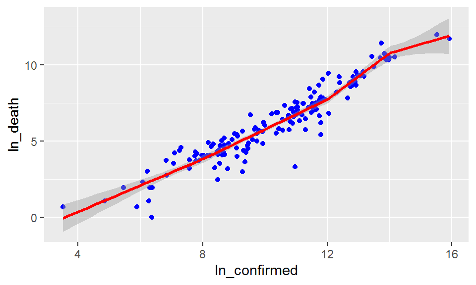

Third model: Piecewise linear spline regression

```
##
## Call:
## lm_robust(formula = ln_death ~ ln_confirmed, data = df, weights = population)
##
## Weighted, Standard error type:  HC2
##
## Coefficients:
##              Estimate Std. Error t value  Pr(>|t|) CI Lower CI Upper  DF
## (Intercept)   -3.0667     0.9382  -3.269 1.337e-03  -4.9203   -1.213 151
## ln_confirmed   0.9487     0.0744  12.752 9.682e-26   0.8017    1.096 151
##
## Multiple R-squared:  0.9281 ,    Adjusted R-squared:  0.9276
## F-statistic: 162.6 on 1 and 151 DF,  p-value: < 2.2e-16
```

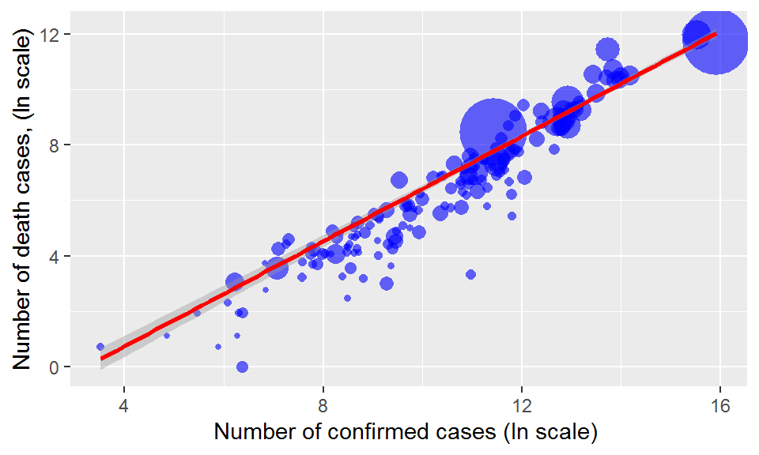

Fourth model: Weighted linear regression, using population as weights

[figure not shown]

Model comparison

[^1]: Center for Systems Science and Engineering